# Optimization

## Goals

To understand the role that GPs can play in optimizing a *blackbox* function,

- i.e., one about which one knows little (it is opaque to the optimizer)
- and which can only be probed through expensive evaluation.

Basically, the idea is to view optimization as an application of sequential design.

The role of "modeling" in optimization has a rich history,

- and we'll barely scratch the surface there.

But the *potential* role of modern *statistical* modeling is just recently being realized by the mathematical programming, statistics, and machine learning communities.

## Surrogate-based optimization

## An old idea

Statistical methods in optimization, in particular of *noisy* blackbox functions, probably goes back to [Box & Draper](https://www.amazon.com/Empirical-Model-Building-Response-Probability-Statistics/dp/0471810339),

- a pre-cursor to "steepest ascent" in classical RSMs.

However, the modern version is closest to methods described by [Mockus, et al. (e.g., 1978)](https://www.researchgate.net/publication/248818761_The_application_of_Bayesian_methods_for_seeking_the_extremum), in a paper entitled

- "The application of Bayesian methods for seeking the extremum".

Although it would seem that many of these ideas were overlooked,

- in part because the models involved were too crude (linear)

until the late 1990's, after GPs became established in the computer experiments literature.

## Surrogate-based optimization

In the computer experiments literature, folks had been using GPs to optimize functions for some time,

- however, the best reference for the core idea might be [Booker, et al. (1999)](http://link.springer.com/article/10.1007/BF01197708).
- They called it *surrogate-based optimization*, and it involved a nice collaboration between optimization and computer modeling researchers.

Observe that Step 2 involves its own inner-optimization,

- but an easy one that can be solved with conventional methods.

## The problem

Before we continue, lets be clear about the problem.

We wish to find

\[ x^* = \mathrm{argmin}_{x \in \mathcal{B}} \; f(x). \]

- \(\mathcal{B}\) is usually a hyper-rectangle.
- We do not have the derivatives of \(f(x)\), nor do we necessarily want them (or want to approximate them).
- The methods we prescribe fall under the class of **derivative-free optimization**, see., e.g., [Conn, et al. (2009)](http://epubs.siam.org/doi/book/10.1137/1.9780898718768).

This means that all we get to do is

- evaluate \(f(x)\), which for now is *deterministic*,
- and we presume that it is expensive to do so (in terms of computing time, say).
- So a tacit "constraint" on the solver is that it minimize the number of evaluations.

## Implementation

Lets consider an implementation of the idea Booker et al. summarized on a re-scaled/coded version of the [Goldstein-Price](http://www.sfu.ca/~ssurjano/goldpr.html) function.

```r
f <- function(X)
 {
    if(is.null(nrow(X))) X <- matrix(X, nrow=1)
    m <- 8.6928
    s <- 2.4269
    x1 <- 4 * X[,1] - 2
    x2 <- 4 * X[,2] - 2
    a <- 1 + (x1 + x2 + 1)^2 * (19 - 14 * x1 + 3 * x1^2 - 14 *
        x2 + 6 * x1 * x2 + 3 * x2^2)
    b <- 30 + (2 * x1 - 3 * x2)^2 * (18 - 32 * x1 + 12 * x1^2 +
        48 * x2 - 36 * x1 * x2 + 27 * x2^2)
    f <- log(a * b)
    f <- (f - m)/s
    return(f)
 }
```

- We want to minimize this \(f(x)\), pretending we can't see how it is comprised.

## Initial design

Lets start with a small initial design in the 2d space.

```r
library(lhs)
ninit <- 12
X <- randomLHS(ninit, 2)
y <- f(X)
```

Now lets fit a (separable) GP to that data, with a small nugget.

```r
library(laGP)
gpi <- newGPsep(X, y, d=0.1, g=1e-6, dK=TRUE)
da <- darg(list(mle=TRUE, max=0.5), X)
mleGPsep(gpi, param="d", tmin=da$min, tmax=da$max, ab=da$ab)$msg
```

```
## [1] "CONVERGENCE: REL_REDUCTION_OF_F <= FACTR*EPSMCH"
```

## Surrogate-optimize

Just like our ALM/C searches, lets set up an objective that we can search based on the predictive distribution.

```r
obj.mean <- function(x, gpi) predGPsep(gpi, matrix(x, nrow=1), lite=TRUE)$mean
```

Now the predictive surface (like the function \(f\)) may have many local minima,

- but lets punt on the idea of global optimization for the moment,
- and see where we get with a search initialized at the current best value.

```r
m <- which.min(y)
opt <- optim(X[m,], obj.mean, lower=0, upper=1, method="L-BFGS-B", gpi=gpi)
opt$par
```

```
## [1] 0.4753221 0.1293059
```

- So this is the next point to try.

## One-step of search

Here's what that looks like in the input domain.

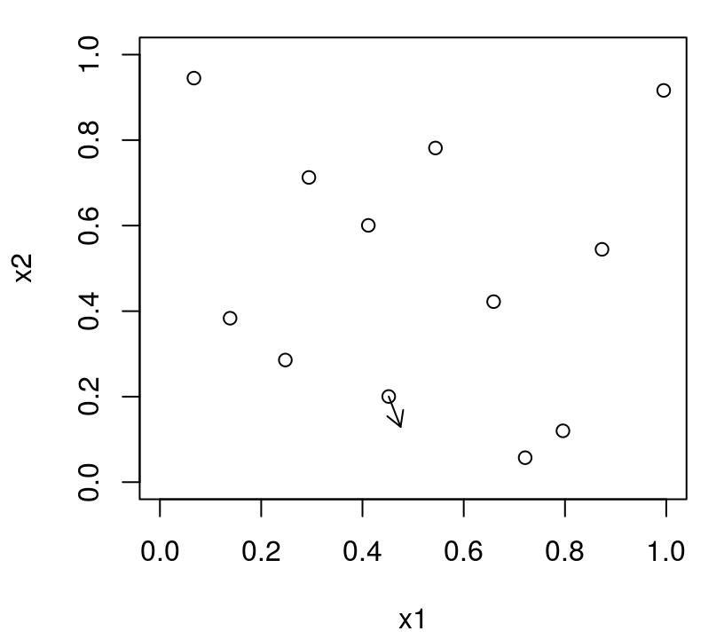

```r
plot(X[1:ninit,], xlab="x1", ylab="x2", xlim=c(0,1), ylim=c(0,1))
arrows(X[m,1], X[m,2], opt$par[1], opt$par[2], length=0.1)
```

## Another iteration

Evaluate \(f\) at `opt$par`, update the GP …

```r
ynew <- f(opt$par)
updateGPsep(gpi, matrix(opt$par, nrow=1), ynew)
mle <- mleGPsep(gpi, param="d", tmin=da$min, tmax=da$max, ab=da$ab)
X <- rbind(X, opt$par)
y <- c(y, ynew)
```

… and solve for the next point.

```r
m <- which.min(y)
opt <- optim(X[m,], obj.mean, lower=0, upper=1,  method="L-BFGS-B", gpi=gpi)
opt$par
```

```
## [1] 0.4254130 0.2121648
```

Here's what that looks like in the input domain.

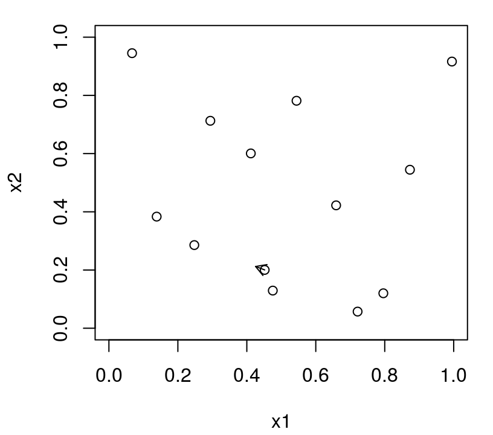

```r
plot(X, xlab="x1", ylab="x2", xlim=c(0,1), ylim=c(0,1))
n <- nrow(X)
arrows(X[m,1], X[m,2], opt$par[1], opt$par[2], length=0.1)
```

Update for the most recent point.

```r
ynew <- f(opt$par)
updateGPsep(gpi, matrix(opt$par, nrow=1), ynew)
mle <- mleGPsep(gpi, param="d", tmin=da$min, tmax=da$max, ab=da$ab)
X <- rbind(X, opt$par)
y <- c(y, ynew)
```

```r
while(1) {
    m <- which.min(y)
    opt <- optim(X[m,], obj.mean, lower=0, upper=1,
        method="L-BFGS-B", gpi=gpi)
    ynew <- f(opt$par)
    if(abs(ynew - y[length(y)]) < 1e-4) break;
    updateGPsep(gpi, matrix(opt$par, nrow=1), ynew)
    mle <- mleGPsep(gpi, param="d", tmin=da$min, tmax=da$max, ab=da$ab)
    X <- rbind(X, opt$par)
    y <- c(y, ynew)
}
```

## Progress

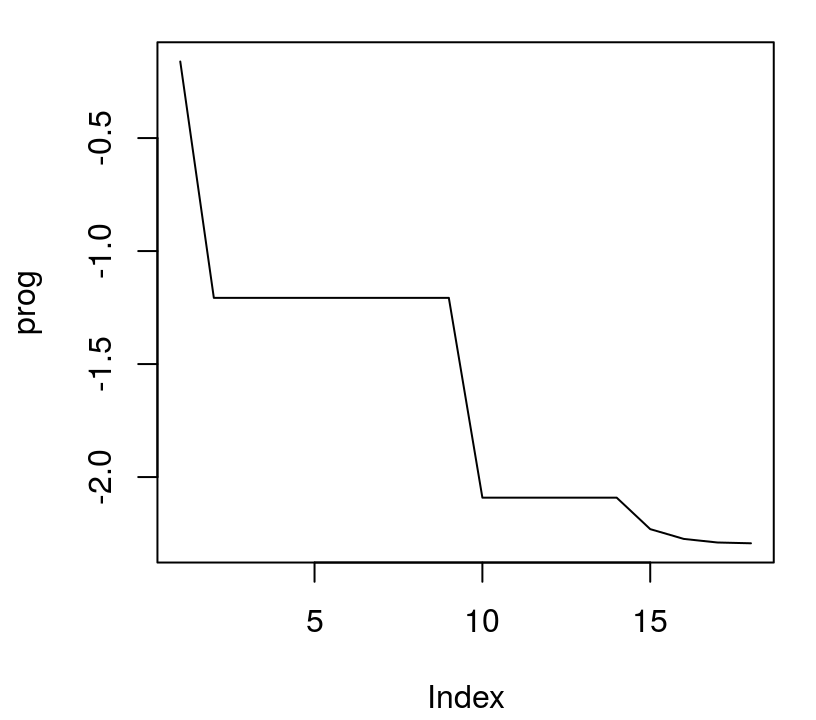

```r
prog <- y
for(i in 2:length(y))
    if(prog[i] > prog[i-1]) prog[i] <- prog[i-1]
plot(prog, type="l")
```

## Encapsulating function

```r
optim.surr <- function(f, ninit, stop, tol=1e-4)
 {
    X <- randomLHS(ninit, 2)
    y <- f(X)
    gpi <- newGPsep(X, y, d=0.1, g=1e-7, dK=TRUE)
    da <- darg(list(mle=TRUE, max=0.5), randomLHS(1000, 2))
    mleGPsep(gpi, param="d", tmin=da$min, tmax=da$max, ab=da$ab)
    for(i in (ninit+1):stop) {
        m <- which.min(y)
        opt <- optim(X[m,], obj.mean, lower=0, upper=1,
            method="L-BFGS-B", gpi=gpi)
        ynew <- f(opt$par)
        if(abs(ynew - y[length(y)]) < tol) break;
        updateGPsep(gpi, matrix(opt$par, nrow=1), ynew)
        mleGPsep(gpi, param="d", tmin=da$min, tmax=da$max, ab=da$ab)
        X <- rbind(X, opt$par)
        y <- c(y, ynew)
    }
    deleteGPsep(gpi)

    return(list(X=X, y=y))
 }
```

## Average progress under random init

Lets repeatedly solve the problem in this way with 100 random initializations.

```r
reps <- 100
prog <- matrix(NA, nrow=reps, ncol=50)
for(r in 1:reps) {
    os <- optim.surr(f, 12, 50)
    prog[r,1:length(os$y)] <- os$y
    for(i in 2:50) {
        if(is.na(prog[r,i]) || prog[r,i] > prog[r,i-1])
            prog[r,i] <- prog[r,i-1]
    }
}
```

Note that these are random initializations.

- not random searches.
- These searches are completely deterministic.
  - (I.e., this is not *stochastic optimization*.)

## Visualizing average progress

Clearly this is not a global optimization tool.

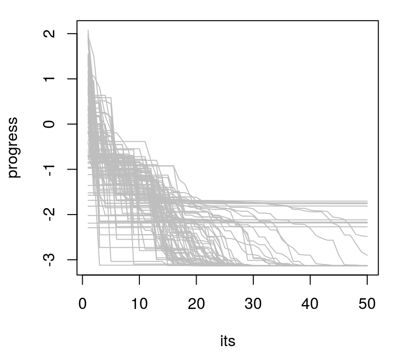

```r
matplot(t(prog), type="l", col="gray", lty=1, ylab="progress", xlab="its")
```

## How does `optim` compare?

First, we need to modify \(f\) so we can keep track of the path of evaluations.

- because `optim` will call \(f\) to approximate gradients.

```r
fprime <- function(x)
 {
    ynew <- f(x)
    y <<- c(y, ynew)
    return(ynew)
 }
```

Now lets loop a bunch of times.

- Note that `optim` will only allow us to control the "outer" iterations.

## Average `optim` progress

Here is the same `for` loop we did with the surrogate-based optimizer,

- with a direct `optim` instead,
- randomly initialized.

```r
prog.optim <- matrix(NA, nrow=reps, ncol=50)
for(r in 1:reps) {
    y <- c()
    os <- optim(runif(2), fprime, lower=0, upper=1, method="L-BFGS-B")
    prog.optim[r,1:length(y)] <- y <- y[1:min(50, length(y))]
    for(i in 2:length(y)) {
        if(is.na(prog.optim[r,i]) || prog.optim[r,i] > prog.optim[r,i-1])
            prog.optim[r,i] <- prog.optim[r,i-1]
    }
}
```

## Clear winner

`optim` progress is much slower on a fixed budget.

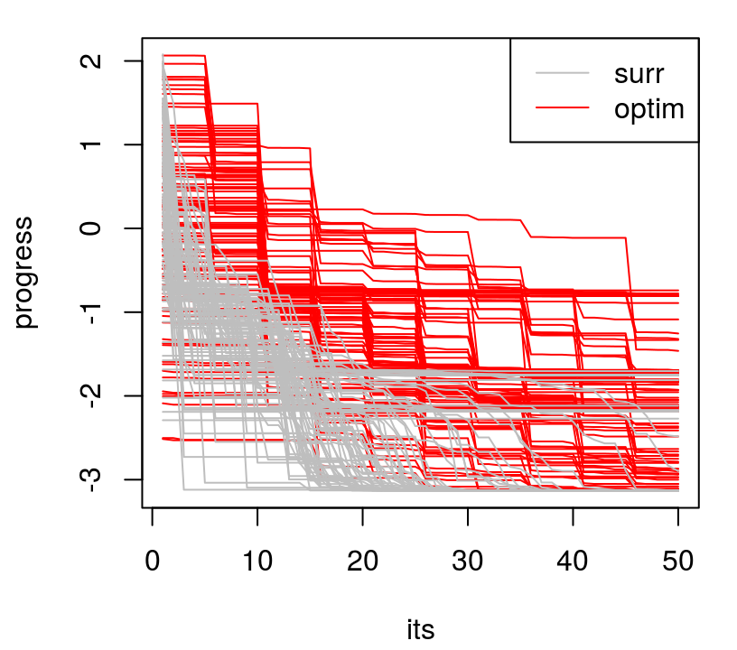

```r
matplot(t(prog.optim), type="l", col="red", lty=1, ylab="progress", xlab="its")
matlines(t(prog), type="l", col="gray", lty=1)
legend("topright", c("surr", "optim"), col=c("gray", "red"), lty=1)
```

## Why do "we" do well?

Our surrogate-based optimization is more efficient because

- it does not need to evaluate the expensive blackbox function, \(f\), to approximate derivatives.
- Rather, the surrogate is providing a sense of derivative for "free".
- It also can (potentially) take big steps because its knowledge of the response surface is more global than `optim`'s.
  - `optim` only bases evaluations on a local linear approximation.

## How can "we" do better?

But surrogate optimization is still mostly a local affair.

- It *exploits*, by moving to the next best spot from where it left off,
- descending with its own `optim` subroutine on the predictive surface.
- It does not *explore* places that cannot easily be reached from the current best value.

We need some way to balance exploration and exploitation.

- BTW, notice that we're not actually doing statistics,
- because at no point is uncertainty being taken into account.

## Expected improvement

## Striking a balance

In the mid 90s, Matthias Schonlau was working on his [dissertation](http://www.schonlau.net/publication/thesis1side.pdf),

- which basically revisited Mockus' Bayesian optimization idea from a Gaussian process and computer experiments perspective.

He came up with a heuristic called **expected improvement (EI)**, which is the basis of a so-called

- **efficient global optimization (EGO)** algorithm.

His key insight was that predictive uncertainty was underutilized in the surrogate framework for optimization,

- which is especially a shame when GPs are involved, because they provide such a beautiful predictive variance function.
- The basic idea, however, is not limited to GP surrogates.

## Improvement

Schonlau defined a statistic called the **improvement**

\[ I(x) = \max\{0, f^{\mathrm{min}}_n - Y(x)\} \]

which is a *random variable* measuring the amount by which an unknown response \(Y(x)\) is below the current point known to be the minimum

\[ f^{\mathrm{min}}_n = \min \{y_1, \dots, y_n\}. \]

- That is, measuring potential of \(Y(x)\) to "improve" upon the current best minimum.
- If \(Y(x)\) has non-zero probability of taking on any value on the real line, then \(I(x)\) has nonzero probability of being positive.

## Expected improvement

Now there are lots of things you could imagine doing with the improvement,

- but probably the most important thing to do (to make it useful) is to remove the randomness.
- And the simplest way to do that is to take an expectation.

It is easiest to imagine what the **expected improvement** might look like through a Monte Carlo approximation.

- Draw \(y^{(t)} \sim \mathcal{N}(\mu(x), \sigma^2(x))\) in the case of Gaussian \(Y(x)\), \(t=1,\dots, T\).
- And average:

\[ \frac{1}{T} \sum_{t=0}^T \max\{0, f^n_\min - y^{(t)} \} \rightarrow \mathbb{E}\{I(x)\} \quad \mbox{ as } T \rightarrow \infty. \]

- This works no matter what the distribution of \(Y(x)\) is (so long as you can simulate from it).

## Analytic expression

The cool thing is that if \(Y(x)\) is Gaussian,

- as it is under the predictive equations of a GP,

the EI has a convenient closed form expression.

\[ \mathbb{E}\{I(x)\} = (f^n_{\min} - \mu_n(x))\,\Phi\!\left( \frac{f^n_{\min} - \mu_n(x)}{\sigma_n(x)}\right) + \sigma_n(x)\, \phi\!\left( \frac{f^n_{\min} - \mu_n(x)}{\sigma_n(x)}\right) \]

- \(\Phi\) and \(\phi\) are the standard normal cdf and pdf, respectively.

Notice how it organically balances

- exploitation: \(\mu_n(x)\) below \(f_\min^n\), and
- exploration: large \(\sigma_n(x)\).

– A useful cartoon –

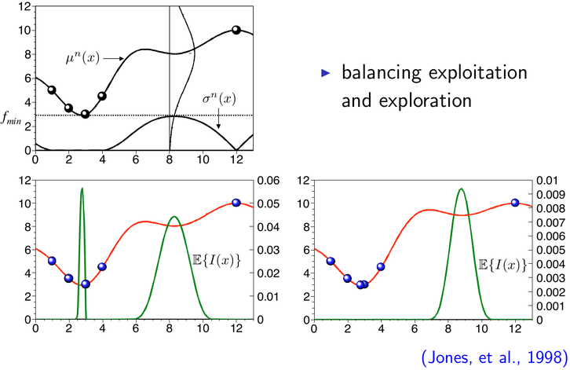

## Interactive EI demo

See `gp_ei_sin.R` with the course materials.

This code uses a hodge-podge of libraries, and I didn't want to re-write it.

- We'll code our own stuff up in a sec.

## Our own EI calculation

The `laGP` package doesn't include an EI calculation,

- but it is easy to use the output of the predict functions to calculate EI.

```r
EI <- function(gpi, x, fmin, pred=predGPsep)
 {
    if(is.null(nrow(x))) x <- matrix(x, nrow=1)
    p <- pred(gpi, x, lite=TRUE)
    d <- fmin - p$mean
    sigma <- sqrt(p$s2)
    dn <- d/sigma
    ei <- d*pnorm(dn) + sigma*dnorm(dn)
    return(ei)
 }
```

To use it as an objective in a surrogate-based optimization:

```r
obj.EI <- function(x, fmin, gpi) - EI(gpi, x, fmin)
```

## Multi-start scheme

Although EI has a "maximizing variance" aspect, which could cause the EI surface to be multi-modal

- just like ALM and ALC,
- it will not be as pathologically so.

The number of EI modes will fluctuate as the algorithm runs,

- but eventually it will resemble the actual (number of) modes in \(f\).

Therefore a sensible multi-start scheme might include

- the best point you have so far (\(f^n_\min\))
- and a few other points spread around the input space.

## A search scheme

Copying from `alm.search`, how about the following?

```r
EI.search <- function(X, y, gpi, multi.start=5)
 {
    m <- which.min(y)
    fmin <- y[m]
    start <- matrix(X[m,], nrow=1)
    if(multi.start > 1)
        start <- rbind(start, randomLHS(multi.start-1, ncol(X)))
    xnew <- matrix(NA, nrow=nrow(start), ncol=ncol(X)+1)
    for(i in 1:nrow(start)) {
        if(EI(gpi, start[i,], fmin) <= eps)
            { out <- list(value=-Inf); next }
        out <- optim(start[i,], obj.EI, method="L-BFGS-B",
            lower=0, upper=1, gpi=gpi, fmin=fmin)
        xnew[i,] <- c(out$par, -out$value)
    }
    solns <- data.frame(cbind(start, xnew))
    names(solns) <- c("s1", "s2", "x1", "x2", "val")
    solns <- solns[(solns$val > sqrt(.Machine$double.eps)),]
    return(solns)
}
```

## Initializing an EI search

Initializing the GP fit.

```r
X <- randomLHS(ninit, 2)
y <- f(X)
gpi <- newGPsep(X, y, d=0.1, g=1e-6, dK=TRUE)
da <- darg(list(mle=TRUE, max=0.5), X)
```

Performing an EI search.

```r
solns <- EI.search(X, y, gpi)
m <- which.max(solns$val)
maxei <- solns$val[m]
```

## First iteration visualized

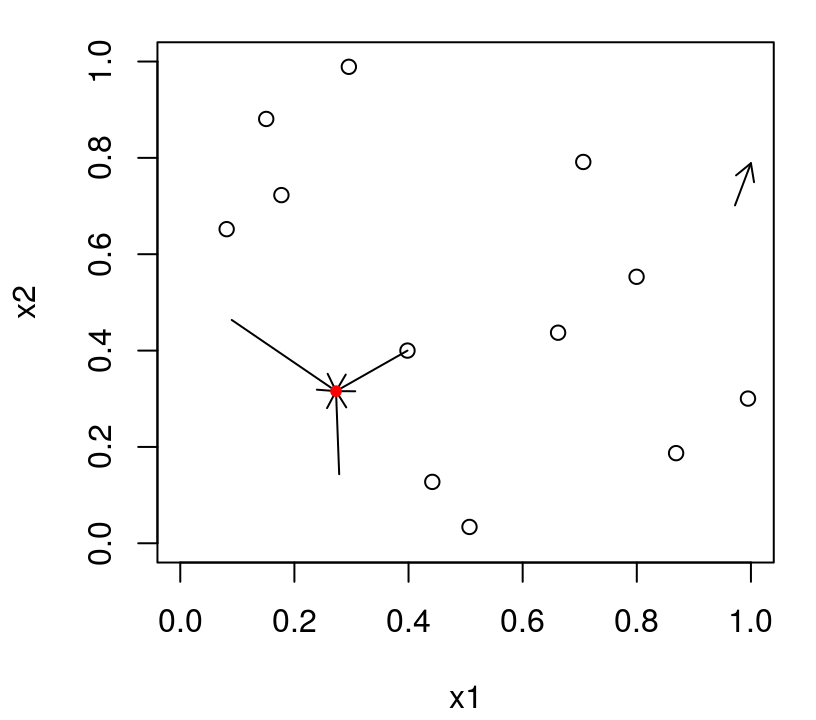

```r
plot(X, xlab="x1", ylab="x2", xlim=c(0,1), ylim=c(0,1))
arrows(solns$s1, solns$s2, solns$x1, solns$x2, length=0.1)
points(solns$x1[m], solns$x2[m], col=2, pch=20)
```

## Next iteration

Incorporate the new data at the chosen input location.

```r
xnew <- as.matrix(solns[m,3:4])
X <- rbind(X, xnew)
y <- c(y, f(xnew))
updateGPsep(gpi, xnew, y[length(y)])
mle <- mleGPsep(gpi, param="d", tmin=da$min, tmax=da$max, ab=da$ab)
```

And do another iteration, and update.

```r
solns <- EI.search(X, y, gpi)
m <- which.max(solns$val)
maxei <- c(maxei, solns$val[m])
xnew <- as.matrix(solns[m,3:4])
X <- rbind(X, xnew)
y <- c(y, f(xnew))
updateGPsep(gpi, xnew, y[length(y)])
mle <- mleGPsep(gpi, param="d", tmin=da$min, tmax=da$max, ab=da$ab)
```

Clearly a multi-modal criteria.

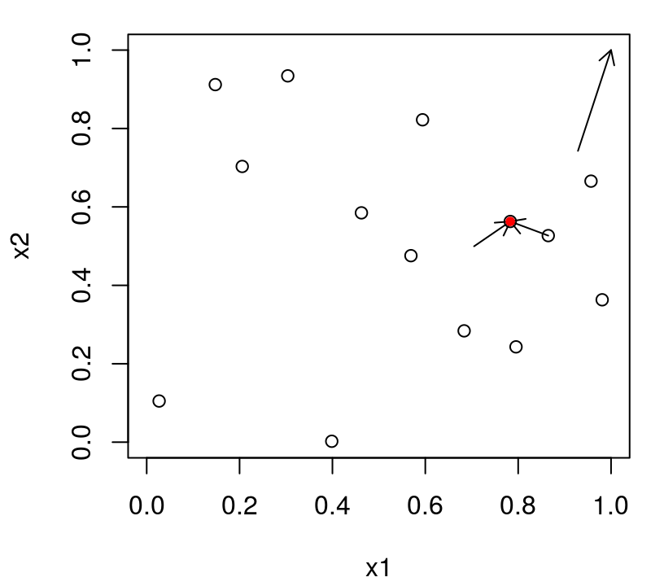

```r
plot(X, xlab="x1", ylab="x2", xlim=c(0,1), ylim=c(0,1))
arrows(solns$s1, solns$s2, solns$x1, solns$x2, length=0.1)
points(solns$x1[m], solns$x2[m], col=2, pch=20)
```

## More iterations

**Careful**, similar \(y\)-values is no longer a good measure of convergence.

```r
for(i in nrow(X):50) {
    solns <- EI.search(X, y, gpi)
    m <- which.max(solns$val)
    maxei <- c(maxei, solns$val[m])
    xnew <- as.matrix(solns[m,3:4])
    ynew <- f(xnew)
    X <- rbind(X, xnew); y <- c(y, ynew)
    updateGPsep(gpi, xnew, y[length(y)])
    mle <- mleGPsep(gpi, param="d", tmin=da$min, tmax=da$max, ab=da$ab)
}
```

Calculating progress …

```r
prog.ei <- y
for(i in 2:length(y))
    if(prog.ei[i] > prog.ei[i-1]) prog.ei[i] <- prog.ei[i-1]
```

## Two measures of progress

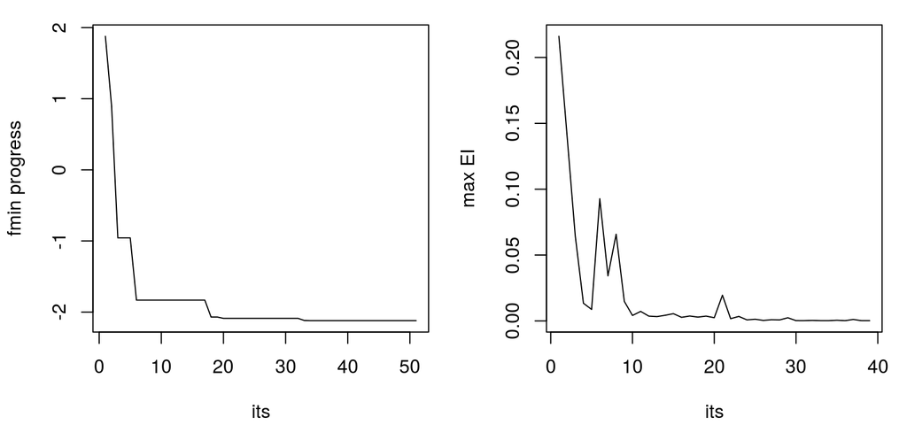

```r
par(mfrow=c(1,2))
plot(prog.ei, type="l", ylab="fmin progress", xlab="its")
plot(maxei, type="l", xlab="its", ylab="max EI")
```

## Encapsulating function

```r
optim.EI <- function(f, ninit, stop)
 {
    X <- randomLHS(ninit, 2); y <- f(X)
    gpi <- newGPsep(X, y, d=0.1, g=1e-7, dK=TRUE)
    da <- darg(list(mle=TRUE, min=eps, max=0.5), X)
    mleGPsep(gpi, param="d", tmin=da$min, tmax=da$max, ab=da$ab)
    maxei <- c()
    for(i in (ninit+1):stop) {
        solns <- EI.search(X, y, gpi)
        m <- which.max(solns$val)
        maxei <- c(maxei, solns$val[m])
        xnew <- as.matrix(solns[m,3:4])
        ynew <- f(xnew)
        updateGPsep(gpi, matrix(xnew, nrow=1), ynew)
        mleGPsep(gpi, param="d", tmin=da$min, tmax=da$max, ab=da$ab)
        X <- rbind(X, xnew); y <- c(y, ynew)
    }
    deleteGPsep(gpi)

    return(list(X=X, y=y, maxei=maxei))
 }
```

## Average progress under random init

Lets repeatedly solve the problem in this way with 100 random initializations.

```r
reps <- 100
prog.ei <- matrix(NA, nrow=reps, ncol=50)
for(r in 1:reps) {
    os <- optim.EI(f, 12, 50)
    prog.ei[r,1:length(os$y)] <- os$y
    for(i in 2:length(os$y)) {
        if(is.na(prog.ei[r,i]) || prog.ei[r,i] > prog.ei[r,i-1])
            prog.ei[r,i] <- prog.ei[r,i-1]
    }
}
```

The next slide shows the average progress of our three methods so far.

- Its getting to messy to look at all the paths.

## Average progress

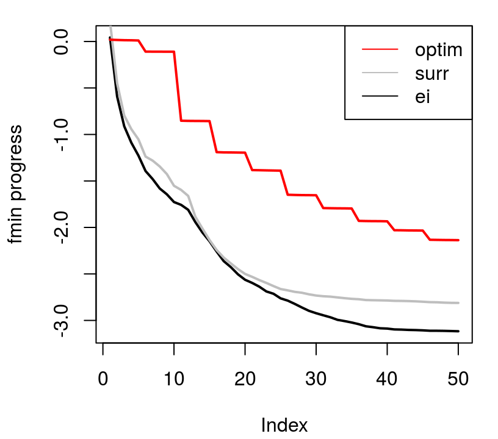

```r
plot(colMeans(prog.ei), col=1, lwd=2, ylab="fmin progress", type="l")
lines(colMeans(prog), col="gray",lwd=2)
lines(colMeans(prog.optim, na.rm=TRUE), col=2,lwd=2)
legend("topright", c("optim", "surr", "ei"), col=c(2, "gray", 1), lty=1)
```

## Final solution

Once or twice out of 100 repeats did EI not find the global min after 50 iterations.

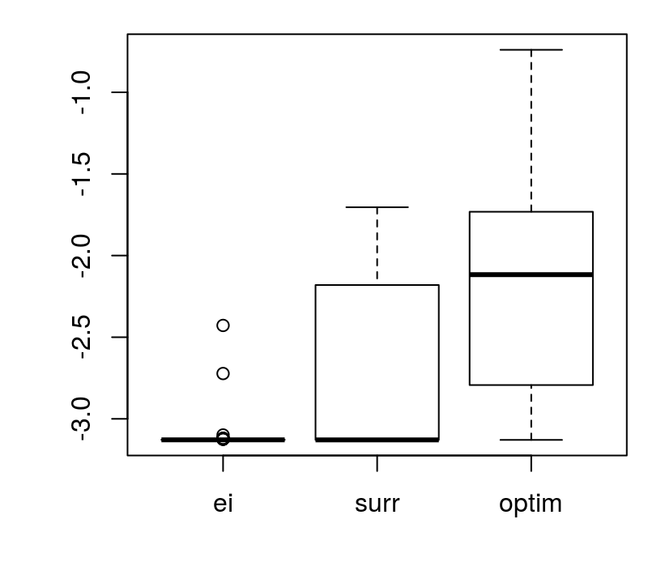

```r
boxplot(prog.ei[,50], prog[,50], prog.optim[,50], names=c("ei", "surr", "optim"))
```

## What can you say about it?

Under certain regularity conditions,

- (and when are those really in touch with reality?)
- like that the hyperparameters are known,

the EGO algorithm (i.e., EI searches) will converge to a global optima.

- But only really in the sense that "eventually it will explore everywhere".

In practice, it does really well

- but there are pathologies;
- just like ALM it can make self-reinforcing decisions, which can be mitigated with strong-ish priors.

You can show that each sequential EI-based decision is optimal

- for the situation where that sample is the last one you'll ever take.

## Conditional improvement

That's suggestive of scope for further improvement with additional "look-ahead",

- like ALC does.

[Gramacy & Lee (2010)](https://arxiv.org/pdf/1004.4027v2.pdf) describe something called the **integrated expected conditional improvement (IECI)**.

- It was designed for optimization under constraints, which we'll get to in a sec.

The **conditional improvement** involves measuring improvement at one location, a reference location \(x\), *after* another location \(x_{n+1}\) is added into the design.

\[ I(x \mid x_{n+1}) = \max \{0, f_\min^n - Y(x \mid x_{n+1}) \} \]

We "deduce" the moments distribution of \(Y(x \mid x_{n+1})\) as follows:

- \(\mathbb{E}\{Y(x \mid x_{n+1})\} = \mu_n(x)\) since \(y_{n+1}\) has not come yet.
- \(\mathbb{V}\mathrm{ar}[Y(x \mid x_{n+1})] = \sigma_{n+1}^2(x)\), calculated via partition inverse equations.

## IECI

Taking the expectation of \(I(x \mid x_{n+1})\) yields the **ECI**

- the analogue of EI for the conditional improvement.

\[ \mathbb{E}\{I(x \mid x_{n+1})\} = (f^n_{\min} - \mu_n(x))\,\Phi\!\left( \frac{f^n_{\min}\!-\!\mu_n(x)}{\sigma_{n+1}(x)}\right) + \sigma_{n+1}(x)\, \phi\!\left( \frac{f^n_{\min}\!-\!\mu_n(x)}{\sigma_{n+1}(x)}\right) \]

Then, to obtain a function of \(x_{n+1}\) only, i.e., a criteria for sequential design, we integrate over the reference point \(x\)

\[ \mathrm{IECI}(x_{n+1}) = - \int_{x\in\mathcal{B}} \mathbb{E}\{I(x \mid x_{n+1})\} w(x) \; dx \]

- yielding the **IECI**, for some (possibly uniform) weights \(w(x)\).
- In practice we approximate with a sum.

## Noisy side-bar

For technical reasons, it is helpful to re-define \(f_\min\),

- to be your *estimated* rather than *observed* minimum.

This is a standard swap in the literature

- which is usually made in order to handle noisy objective functions.
- In IECI it is helpful whether there is noise or not.

When there is noise,

\[ \quad f_\min^n = \min_{x \in \mathcal{B}} \mu_n(x) \approx \min_{x \in X_n} \mu_n(x). \]

- Specifically, we'll use \(f_\min^n = \min_{x \in \mathcal{B}} \mu_n(x)\) going forward.

## IECI and noise

Lets illustrate both (IECI and noisy evaluations) at the same time.

Consider the following data in 1d, to ease visualization.

```r
f1d <- function(x){ return( sin(x) - 2.55*dnorm(x,1.6,0.45) ) }
X <- matrix(c(seq(0, 4.4, length=15), seq(5.3, 7, length=5)), ncol=1)
y <- f1d(X) + rnorm(length(X), sd=0.15)
```

- The design deliberately omits one of the two local minima for illustrative purposes.

The initial fit:

```r
gpi <- newGP(X, y, d=0.1, g=0.1*var(y), dK=TRUE)
mle <- jmleGP(gpi)
```

## Predictive surface

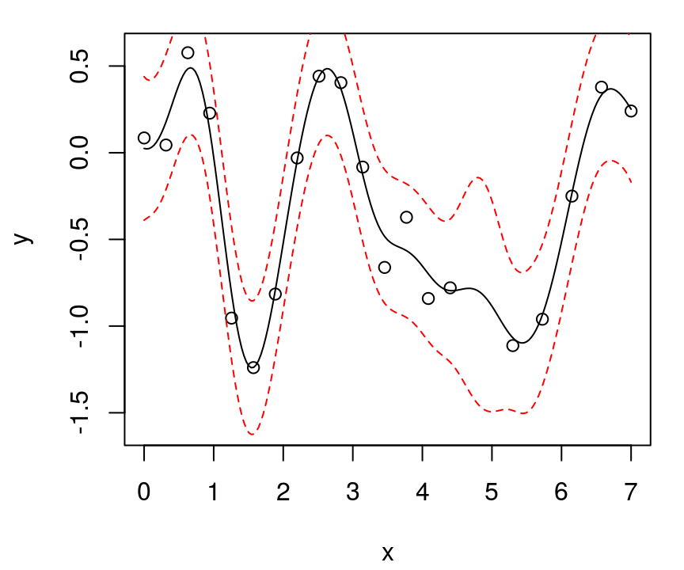

```r
XX <- matrix(seq(0, 7, length=201), ncol=1)
plot(X, y, xlab="x", ylab="y", ylim=c(-1.6,0.6))
p <- predGP(gpi, XX, lite=TRUE); lines(XX, p$mean)
lines(XX, p$mean + 1.96*sqrt(p$s2), col=2, lty=2)
lines(XX, p$mean - 1.96*sqrt(p$s2), col=2, lty=2)
```

Comparing EI and IECI.

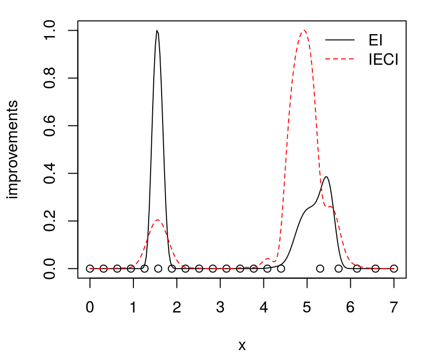

```r
fmin <- min(predGP(gpi, X, lite=TRUE)$mean)
ei <- EI(gpi, XX, fmin, pred=predGP); ei <- ei - min(ei); ei <- ei/max(ei)
ieci <- ieciGP(gpi, XX, fmin); ieci <- ieci - min(ieci); ieci <- ieci/max(ieci)
plot(XX, ei, type="l", ylim=c(0, max(ei)), xlab="x", ylab="improvements")
points(X, rep(0, nrow(X))); lines(XX, 1-ieci, col=2, lty=2)
legend("topright", c("EI", "IECI"), lty=1:2, col=1:2, bty="n")
```

## EI v IECI debrief

IECI is a more aggregate statistic

- pooling together large EI within a wider domain of attraction,
- valuing new design locations by their potential to offer improvement globally in the input space.

Both EI and IECI cope with noise just fine.

I said that IECI was designed for constrained optimization …

## Blackbox constraints

## Known constraints

First, lets keep it simple and assume the constraints are known.

- That means there is a function \(c(x)\) returning
  - zero (or a negative number) if the constraint is satisfied,
  - one (or a positive number) if the constraint is violated
- and we can evaluate it willy-nilly (as much as we want).

The problem is

\[ x^* = \mathrm{argmin}_{x \in \mathcal{B}} \; f(x) \quad \mbox{ subject to } \quad c(x) \leq 0. \]

One simple method is to extend EI to what is called **expected feasible improvement (EFI)** [(Schonlau, Jones & Welch, 1998)](https://www.jstor.org/stable/4356058?seq=1#page_scan_tab_contents)

\[ \mbox{EFI}(x) = \mathbb{E}\{I(x)\} \mathbb{I}(c(x) \leq 0), \]

- precluding choosing any point outside the valid set.

## IECI adaptation

The IECI adaptation involves deploying the indicator \(\mathbb{I}(c(x) \leq 0)\) as a weight \(w(x)\):

\[ \mathrm{IECI}(x_{n+1}) = - \int_{x\in\mathcal{B}} \mathbb{E}\{I(x \mid x_{n+1})\} \mathbb{I}(c(x) \leq 0) \; dx \]

This down-weights *reference* \(x\) values, and thus also \(x_{n+1}\) values,

- however it doesn't preclude \(x_{n+1}\) values from being chosen in the the invalid region.
- Rather, the value of \(x_{n+1}\) is judged by its ability to impact improvement within the valid region.

An alternative implementation, especially when approximating the integral with a sum over `Xref` locations

- is to exclude from `Xref` any input locations which don't satisfy the constraint.

## Known constraint illustration

Lets look at the same 1d data as above, except with the invalid region \([2,4]\).

```r
X <- matrix(c(0.01, 0.25, 0.5, 0.75, 1, 1.15, 1.3, 1.5, 5, 5.25, 5.5,
    5.75, 6, 6.25, 6.5, 6.75, 6.99), ncol=1)
y <- f1d(X) + rnorm(length(X), sd=0.15)
lc <- 2; rc <- 4
Xref <- matrix(c(XX[XX < lc,], XX[XX > rc,]), ncol=1)
```

- Notice that the reference locations encode the constraint.

Lets fit the data, but for the sake of this illustration it makes sense to hard-code a longer lengthscale.

```r
gpi <- newGP(X, y, d=5, g=0.1*var(y), dK=TRUE)
```

- I suggest tinkering with this (also with `jmleGP`) and see how it effects the results.

## Predictive surface

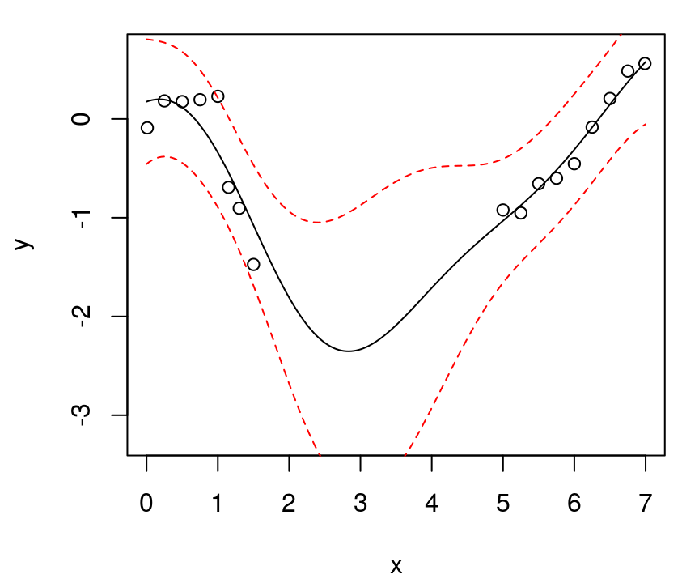

```r
XX <- matrix(seq(0, 7, length=201), ncol=1)
plot(X, y, xlab="x", ylab="y", ylim=c(-3.25, 0.7))
p <- predGP(gpi, XX, lite=TRUE); lines(XX, p$mean)
lines(XX, p$mean + 1.96*sqrt(p$s2), col=2, lty=2)
lines(XX, p$mean - 1.96*sqrt(p$s2), col=2, lty=2)
```

## Calculating EI and IECI

Calculating EI for all `XX` locations.

```r
fmin <- min(predGP(gpi, X, lite=TRUE)$mean)
ei <- EI(gpi, XX, fmin, pred=predGP)
ei <- ei - min(ei); ei <- ei/max(ei)
eiref <- c(ei[XX<lc], ei[XX>rc])
```

- And extracting those which are in the valid region.

Calculating IECI for all `XX` locations, using `Xref` in lieu of weights.

```r
ieci.orig <- ieci <- ieciGP(gpi, XX, fmin, Xref=Xref)
ieci <- ieci - min(ieci); ieci <- ieci/max(ieci)
```

Comparing EI and IECI for a known constraints setup.

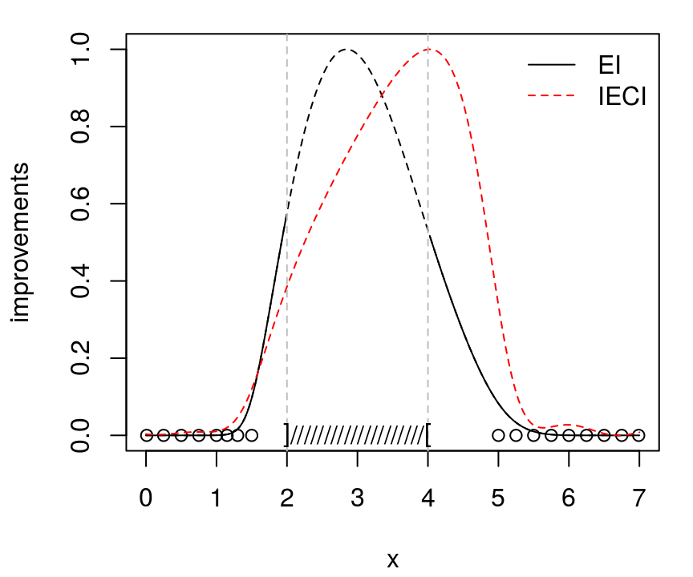

```r
plot(XX, ei, type="l", ylim=c(0, max(ei)), lty=2, xlab="x", ylab="improvements")
lines(Xref[Xref<lc], eiref[Xref<lc]); lines(Xref[Xref>rc], eiref[Xref>rc])
points(X, rep(0, nrow(X))); lines(XX, 1-ieci, col=2, lty=2)
legend("topright", c("EI", "IECI"), lty=1:2, col=1:2, bty="n")
abline(v=c(lc,rc), col="gray", lty=2); text(lc,0,"]"); text(rc,0,"[")
text(seq(lc+.1, rc-.1, length=20), rep(0, 20), rep("/", 20))
```

## Known constraints EI v IECI debrief

I have to admit that, in sequential application, the two methods perform very similarly.

- As do ALM and ALC.
- IECI makes more sense to me but is computationally more demanding (as does/is ALC).
- It depends on how complicated the constraint region is.

But of course, the known constraint setup is very specialized.

- How do we generalize to a unknown (blackbox) constraint setup?

## Blackbox constraints

The problem is unchanged

\[ x^* = \mathrm{argmin}_{x \in \mathcal{B}} \; f(x) \quad \mbox{ subject to } \quad c(x) \leq 0, \]

- but now we can't evaluate the constraint function \(c(x)\) willy-nilly.

We'll need a model for \(c(x)\), and the appropriate model will depend on the nature of the function:

- \(c(x) \in \{0,1\}\) or \(c(x) \in \{0,1\}^m\) for multiple constraints,
  - appropriate for a classification model;
- \(c(x) \in \mathbb{R}\) or \(c(x) \in \mathbb{R}^m\),
  - appropriate for a regression model.

And we can get as fancy or simple as we want with those models and fitting schemes.

## EFI and IECI for blackbox constraints

For now lets generically write \(p^{(j)}_n(x)\) for the *predicted* probability that input \(x\) satisfies the \(j^\mathrm{th}\) constraint, for \(j=1,\dots,k\).

- EFI for blackbox constraints is

\[ \mbox{EFI}(x) = \mathbb{E}\{I(x)\} \prod_{j=1}^m p^{(j)}_n(x) \]

- and similarly IECI:

\[ \mathrm{IECI}(x_{n+1}) = - \int_{x\in\mathcal{B}} \mathbb{E}\{I(x \mid x_{n+1})\} \prod_{j=1}^m p_n^{(j)}(x) \; dx \]

- with similar properties as in the known constraints case.

## Implementation

Lets revisit our earlier 1d known constraint problem, but now pretend we don't know the constraint.

- To grab a flexible model off the shelf we'll use `randomForest`,
- treating the constraint as binary.
- For visualization it will be cleaner to presume that \(c(x) = 1\) is valid and \(c(x) = 0\) is invalid.

A setup like this (GPs/EI/`randomForest`) was first entertained by [Lee et al., (2011)](http://www.ybook.co.jp/online2/oppjo/vol7/p467.html).

## Initializing EFI

Noisy function; deterministic constraint.

```r
ninit <- 7
X <- matrix(randomLHS(ninit, 1)*7, ncol=1)
y <- f1d(X) + rnorm(length(X), sd=0.15)
const <- 1 - as.numeric(X > lc & X < rc)
```

Objective fit.

```r
gpi <- newGP(X, y, d=1, g=0.1*var(y), dK=TRUE)
ga <- garg(list(mle=TRUE), y)
mle <- jmleGP(gpi, drange=c(eps, 10), grange=c(ga$min, ga$max), gab=ga$ab)
```

Constraint fit.

```r
library(randomForest)
cfit <- randomForest(X, as.factor(const))
```

## EFI criteria on a grid

First, calculate \(f_\min^n\) based on the valid observations.

```r
Xv <- X[const <= 0,,drop=FALSE]
fmin <- min(predGP(gpi, Xv, lite=TRUE)$mean)
```

Then evaluate EI and the probability of constraint satisfaction on a predictive grid.

```r
XX <- matrix(seq(0,7,length=201), ncol=1)
pc <- predict(cfit, XX, type="prob")[,2]
ei <- EI(gpi, XX, fmin, pred=predGP)
```

## Visualizing the criteria

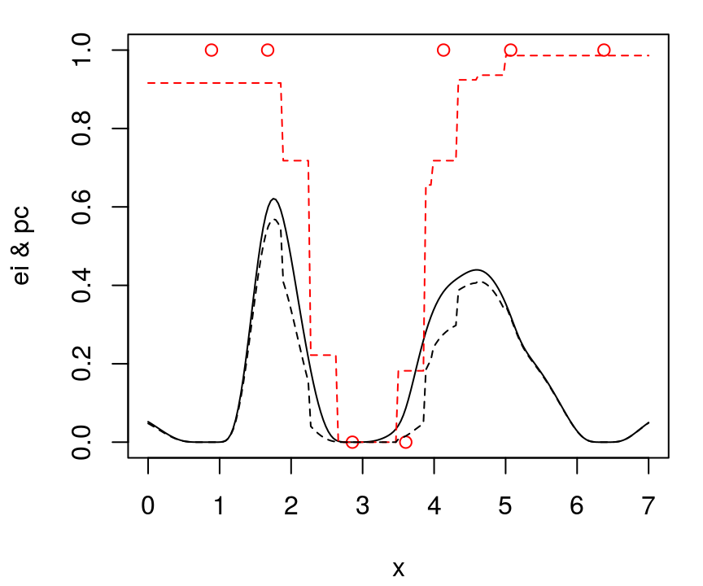

```r
plot(XX, ei, type="l", ylim=c(0,1), xlab="x", ylab="ei & pc")
lines(XX, pc, col=2, lty=2); points(X, const, col=2)
lines(XX, ei*pc, lty=2)
```

## Choosing the next point

Updating fits.

```r
m <- which.max(ei*pc)
X <- rbind(X, XX[m,])
y <- c(y, f1d(XX[m,]) + rnorm(1, sd=0.15))
updateGP(gpi, XX[m,,drop=FALSE], y[length(y)])
mle <- jmleGP(gpi, drange=c(eps, 10), grange=c(ga$min, ga$max), gab=ga$ab)
const <- c(const, 1 - as.numeric(XX[m,] > lc && XX[m,] < rc))
cfit <- randomForest(X, as.factor(const))
XX <- XX[-m,,drop=FALSE]
```

Calculating EFI quantities.

```r
Xv <- X[const <= 0,,drop=FALSE]
fmin <- min(predGP(gpi, Xv, lite=TRUE)$mean)
pc <- predict(cfit, XX, type="prob")[,2]
ei <- EI(gpi, XX, fmin, pred=predGP)
```

## Visualizing the EFI criteria

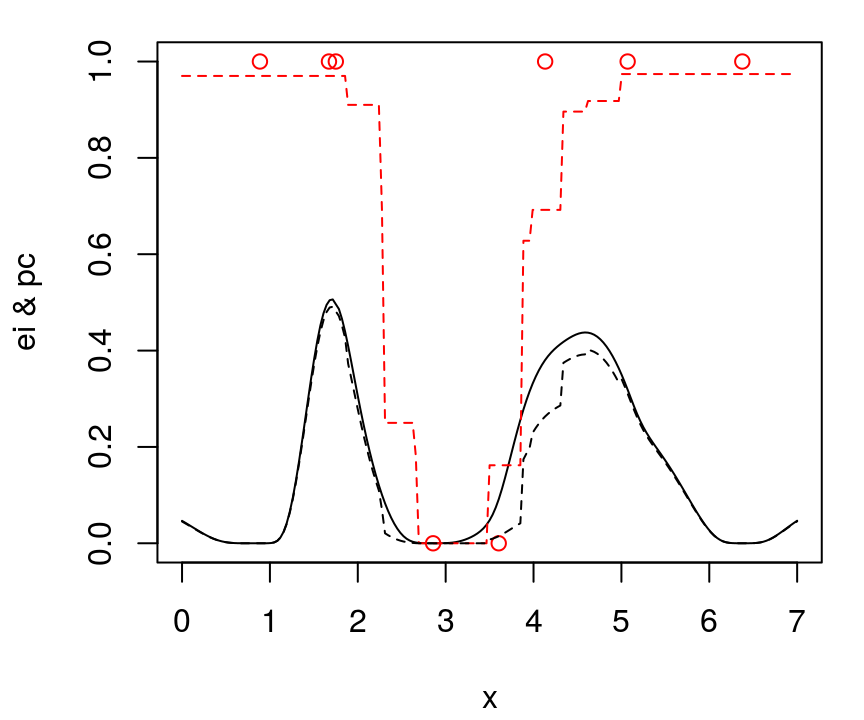

```r
plot(XX, ei, type="l", ylim=c(0,1), xlab="x", ylab="ei & pc")
lines(XX, pc, col=2, lty=2); points(X, const, col=2)
lines(XX, ei*pc, lty=2)
```

Lets put all that in a `for` loop and see where we get.

```r
for(i in 1:15) {
    m <- which.max(ei*pc)
    X <- rbind(X, XX[m,])
    y <- c(y, f1d(XX[m,]) + rnorm(1, sd=0.15))
    updateGP(gpi, XX[m,,drop=FALSE], y[length(y)])
    mle <- jmleGP(gpi, drange=c(eps, 10), grange=c(ga$min, ga$max), gab=ga$ab)
    const <- c(const, 1 - as.numeric(XX[m,] > lc && XX[m,] < rc))
    cfit <- randomForest(X, as.factor(const))
    XX <- XX[-m,,drop=FALSE]
    Xv <- X[const <= 0,,drop=FALSE]
    fmin <- min(predGP(gpi, Xv, lite=TRUE)$mean)
    pc <- predict(cfit, XX, type="prob")[,2]
    ei <- EI(gpi, XX, fmin, pred=predGP)
}
```

## Visualizing the EFI criteria

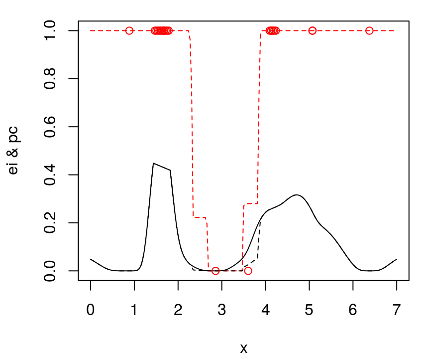

```r
plot(XX, ei, type="l", ylim=c(0,1), xlab="x", ylab="ei & pc")
lines(XX, pc, col=2, lty=2); points(X, const, col=2)
lines(XX, ei*pc, lty=2)
```

## Visualizing the surface

Blue dots show de-noised values of remaining candidates.

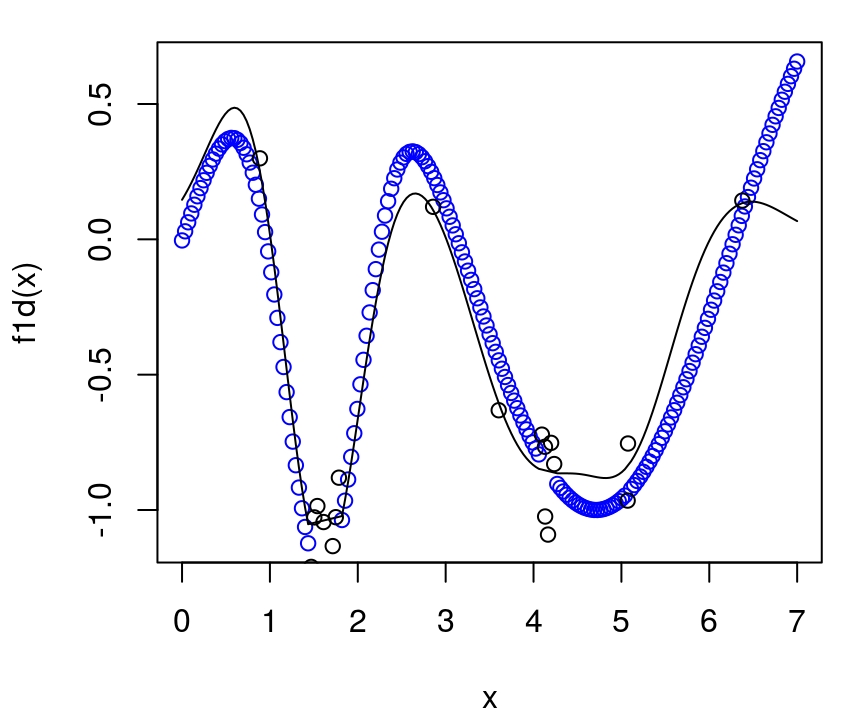

```r
p <- predGP(gpi, XX, lite=TRUE)
plot(XX, f1d(XX), col="blue", xlab="x", ylab="f1d(x)")
points(X,y); lines(XX, p$mean)
```

## Now IECI

Re-initialize the fit.

```r
X <- X[1:ninit,,drop=FALSE]
y <- y[1:ninit]
const <- const[1:ninit]
gpi <- newGP(X, y, d=1, g=0.1*var(y), dK=TRUE)
mle <- jmleGP(gpi, drange=c(eps, 10), grange=c(ga$min, ga$max), gab=ga$ab)
cfit <- randomForest(X, as.factor(const))
```

Calculate IECI.

```r
Xv <- X[const <= 0,,drop=FALSE]
fmin <- min(predGP(gpi, Xv, lite=TRUE)$mean)
XX <- matrix(seq(0,7,length=201), ncol=1)
pc <- predict(cfit, XX, type="prob")[,2]
ieci <- ieciGP(gpi, XX, fmin, w=pc)
ieci <- ieci - min(ieci); ieci <- ieci/max(ieci)
```

## Visualizing the IECI criteria

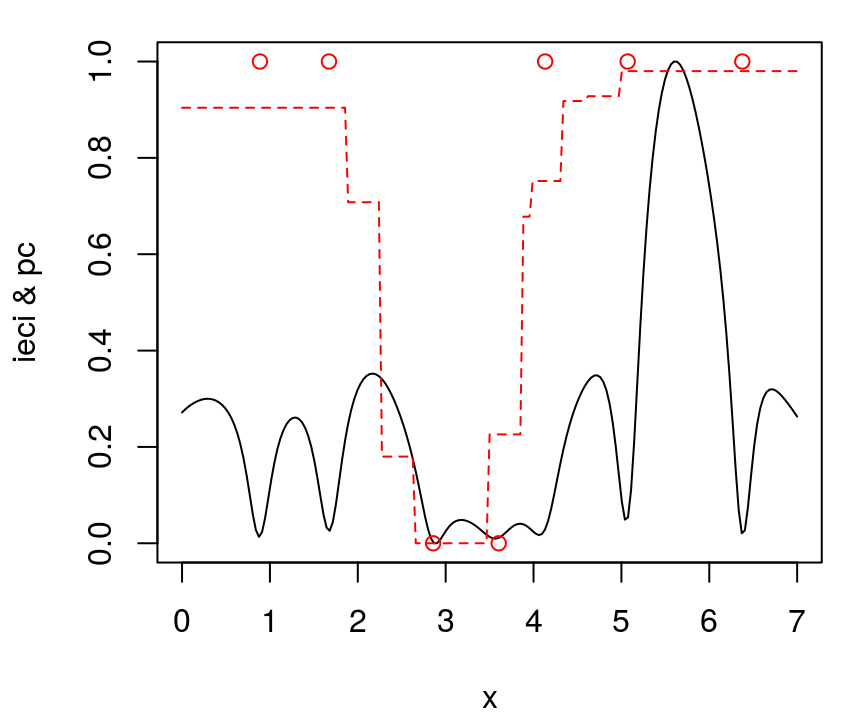

```r
plot(XX, 1-ieci, type="l", ylim=c(0,1), xlab="x", ylab="ieci & pc")
lines(XX, pc, col=2, lty=2); points(X, const, col=2)
```

## Choosing the next point

Updating fits.

```r
m <- which.min(ieci)
X <- rbind(X, XX[m,])
y <- c(y, f1d(XX[m,]) + rnorm(1, sd=0.15))
updateGP(gpi, XX[m,,drop=FALSE], y[length(y)])
mle <- jmleGP(gpi, drange=c(eps, 10), grange=c(ga$min, ga$max), gab=ga$ab)
const <- c(const, 1 - as.numeric(XX[m,] > lc && XX[m,] < rc))
cfit <- randomForest(X, as.factor(const))
XX <- XX[-m,,drop=FALSE]
```

Calculating IECI quantities.

```r
Xv <- X[const <= 0,,drop=FALSE]
fmin <- min(predGP(gpi, Xv, lite=TRUE)$mean)
pc <- predict(cfit, XX, type="prob")[,2]
ieci <- ieciGP(gpi, XX, fmin, w=pc)
ieci <- ieci - min(ieci); ieci <- ieci/max(ieci)
```

## Visualizing the IECI criteria

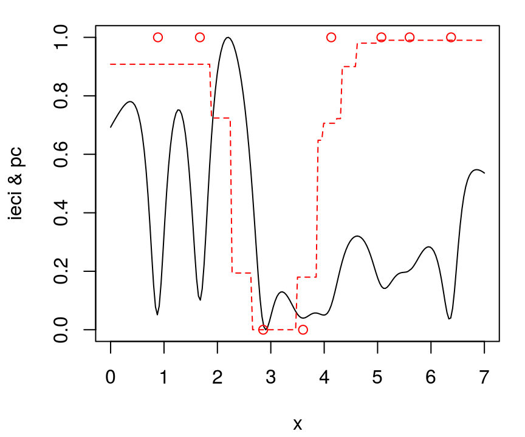

```r
plot(XX, 1-ieci, type="l", ylim=c(0,1), xlab="x", ylab="ieci & pc")
lines(XX, pc, col=2, lty=2); points(X, const, col=2)
```

Lets put all that in a `for` loop and see where we get.

```r
for(i in 1:15) {
    m <- which.min(ieci)
    X <- rbind(X, XX[m,])
    y <- c(y, f1d(XX[m,]) + rnorm(1, sd=0.15))
    updateGP(gpi, XX[m,,drop=FALSE], y[length(y)])
    mle <- jmleGP(gpi, drange=c(eps, 10), grange=c(ga$min, ga$max), gab=ga$ab)
    const <- c(const, 1 - as.numeric(XX[m,] > lc && XX[m,] < rc))
    cfit <- randomForest(X, as.factor(const))
    XX <- XX[-m,,drop=FALSE]
    Xv <- X[const <= 0,,drop=FALSE]
    fmin <- min(predGP(gpi, Xv, lite=TRUE)$mean)
    pc <- predict(cfit, XX, type="prob")[,2]
    ieci <- ieciGP(gpi, XX, fmin, w=pc)
    ieci <- ieci - min(ieci); ieci <- ieci/max(ieci)
}
```

## Visualizing the IECI criteria

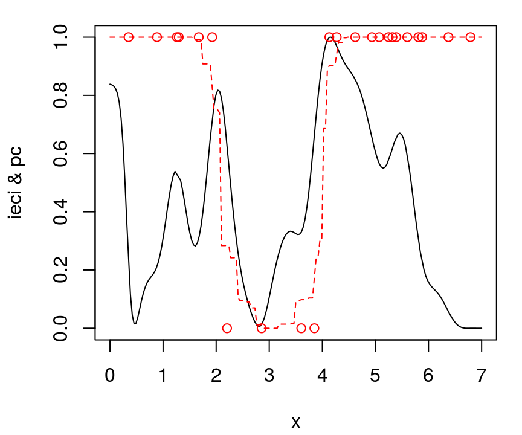

```r
plot(XX, 1-ieci, type="l", ylim=c(0,1), xlab="x", ylab="ieci & pc")
lines(XX, pc, col=2, lty=2); points(X, const, col=2)
```

## Visualizing the surface

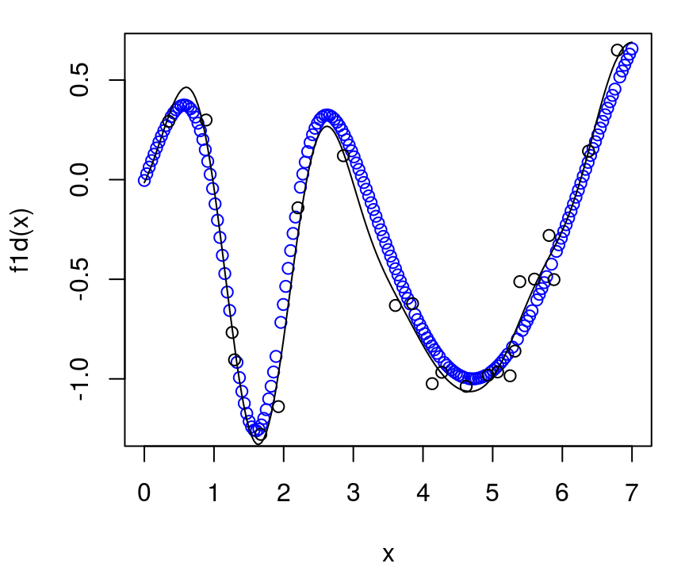

```r
p <- predGP(gpi, XX, lite=TRUE)
plot(XX, f1d(XX), col="blue", xlab="x", ylab="f1d(x)")
points(X,y); lines(XX, p$mean)
```

## Real-valued constraint functions

It is perhaps more typical for the constraint functions to be real-valued, and for there to be multiple such constraints.

- This simplifies matters somewhat, because there are generally more modeling choices for real-valued simulations (e.g., GPs).
- Evaluations of \(c_n^{(j)}(x) \in \mathbb{R}\) provide extra information (compared to \(\{0,1\}\)) comprising of the *distance* to feasibility.
- But multiple constraints obviously makes the overall problem more challenging.

EFI and IECI remain unchanged as general strategies

- suffice it that a probability of constraint satisfaction \(p_n^{(j)}(x) = \mathbb{P}(c_n^{(j)}(x) \leq 0)\) can be backed out of the fitted surfaces \(c_n^{(j)}(x)\) for each constraint \(j=1, \dots, m\).
- For GPs this readily available from the CDF \(\Phi\), i.e., `pnorm` given \(\mu_n^{(j)}(x)\) and \(\sigma_n^{(j)2}(x)\).

## Focus on constraints

So far we have focused primarily on the objective,

- but in many real world "optimization" problems, the constraints steal the show.

There are plenty of challenging problems where the objective is simple/known (e.g., linear),

- but simulation-based constraints
  - require heavy computation
  - are highly non-linear and non-convex, and therefore create many (deceptive) local minima in the input domain.
- This can make for a hard optimization problem.

## For example

Here is a toy problem to fix ideas.

- A linear objective in two variables

\[ \min_{x} \left\{ x_1+x_2 : c_1(x) \leq 0, \, c_2(x) \leq 0, \, x\in [0,1]^2 \right\} \]

- where two non-linear constraints are given by

\[ \begin{aligned} c_1(x) &= \frac{3}{2} - x_1 - 2x_2 - \frac{1}{2}\sin\left(2\pi(x_1^2-2x_2)\right) \\ c_2(x) &= x_1^2+x_2^2-\frac{3}{2} \end{aligned} \]

Even when treating \(f(x) = x_1 + x_2\) as known, this is a hard problem when \(c(x)\) is treated as a blackbox.

## Visualizing the toy problem

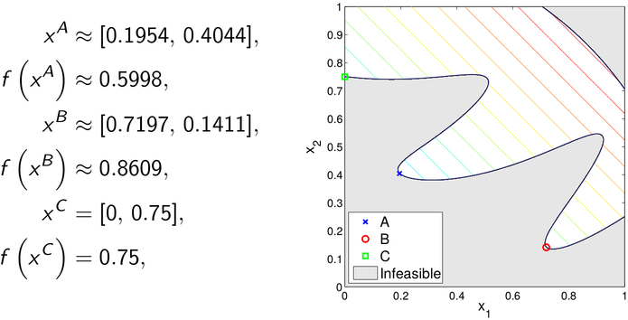

- \(c_2(x)\) may seem uninteresting, but it reminds us that solutions may not exist on every boundary.

## Hybridization

Math programming has efficient algorithms for non-linear (blackbox) optimization (under constraints) with

- provable *local* convergence properties,
- lots of polished open-source software.

Whereas statistical approaches

- enjoy global convergence properties,
- excel when simulation is expensive, noisy, non-convex,

they offer limited support for constraints.

## Augmented Lagrangian

One such framework involves the so-called the **augmented Lagrangian (AL)**:

\[ L_A(x;\lambda, \rho) = f(x) +\lambda^\top c(x) + \frac{1}{2\rho} \sum_{j=1}^m \max \left(0,c_j(x) \right)^2, \quad \mbox{ where} \]

- \(\rho > 0\) is a penalty parameter
- \(\lambda \in \mathbb{R}_+^m\) serves as a Lagrange multiplier

AL-based methods thereby

- transform a constrained problem into a *sequence* of simply constrained ones.

Without the Lagrangian term \(\lambda^\top c(x)\),

- one obtains (an example of) a so-called **additive penalty method (APM)**.
- The full AL advantage is automatic updates of the parameters \((\lambda, \rho)\).

## AL sequence

Given \((\rho^{k-1}, \lambda^{k-1})\),

1. approximately solve the **subproblem** \[ x^k = \mbox{arg}\min_x \left\{ L_A(x;\lambda^{k-1},\rho^{k-1}) : x\in \mathcal{B}\right\} \]
2. update:
   - \(\lambda_j^k = \max\left(0,\lambda_j^{k-1}+\frac{1}{\rho^{k-1}} c_j(x^k) \right)\), \(j=1, \ldots, m\).
   - If \(c(x^k)\leq 0\), set \(\rho^k=\rho^{k-1}\); otherwise, set \(\rho^k=\frac{1}{2}\rho^{k-1}\)
3. … then repeat, incrementing \(k\).
- Functions \(f\) and \(c\) are only evaluated when solving the **subproblem(s)**, comprising an "inner loop".

## Interactive AL demo

See `wildprob.R` with the course material.

## Convergence

AL methods are not designed for global optimization, however the convergence results have a certain robustness.

Even if the "inner" sub-problem

\[ x^k = \mbox{arg}\min_x \left\{ L_A(x;\lambda^{k-1},\rho^{k-1}) : x\in \mathcal{B}\right\} \]

cannot be solved exactly,

- "outer" iterations will converge so long as the "inner" problem makes "progress".
- (Similar to EM or weak learner results.)

How is "outer" convergence determined?

- In our setting, we'll have a maximal computational budget.
- But you could stop when all constraints are satisfied, and the gradient of the Lagrangian is sufficiently small.

## Statistical inner solver

- Derivative-free solvers are an option.
- Of course, we'll focus on methods based on statistical surrogates, and hope for a more global searching flavor.

The idea is to train the "inner" solver with all evaluations

\[ (x_1, f(x_1), c(x_1)), \dots, (x_n, f(x_n), c(x_n)) \]

collected over all "inner" and "outer" loops [(Gramacy, et al., 2016)](http://amstat.tandfonline.com/doi/full/10.1080/00401706.2015.1014065).

- Whereas in a more conventional approach, each "inner" solver would be independent of the next one.

## Separated modeling

Consider a separate/independent GP model each component of the AL.

- \(f^n\) emitting \(Y_{f^n}(x)\)
- \(c^n = (c_1^n, \dots, c_m^n)\) emitting \(Y_c^n(x) = (Y_{c_1}^n(x), \dots, Y_{c_m}^n(x))\)

The distribution of the **composite random variable**

\[ Y(x) = Y_f(x) + \lambda^\top Y_c(x) + \frac{1}{2\rho} \sum_{j=1}^m \max(0, Y_{c_j}(x))^2 \]

can serve as a surrogate for \(L_A(x; \lambda, \rho)\).

- Simplifications when \(f\) is known.

## Tractable surrogate for `optim`

The composite posterior mean is available in closed form, e.g., under GP priors.

\[ \mathbb{E} \{ Y(x)\} = \mu_f^n(x) + \lambda^\top \mu_c^n(x) + \frac{1}{2\rho} \sum_{j=1}^m \mathbb{E}\{ \max(0, Y_{c_j}(x))^2\} \]

A result from generalized EI [(Schonlau, Jones & Welch, 1998)](https://www.jstor.org/stable/4356058?seq=1#page_scan_tab_contents) helps us work out the expectation inside that sum above.

\[ \begin{aligned} & \mathbb{E} \{ \max(0, Y_{c_j}(x))^2\} = \mathbb{E}\{I_{-Y_{c_j}}(x)\}^2 + \mathbb{V}\mathrm{ar}[I_{-Y_{c_j}}(x)] \\ &= \sigma^{2n}_{c_j}(x)\left[\left( 1+ \left(\frac{\mu^n_{c_j}(x)}{\sigma_{c_j}^n(x)}\right)^{2}\right) \Phi\left(\frac{\mu^n_{c_j}(x)}{\sigma_{c_j}^n(x)} \right) +\frac{\mu^n_{c_j}(x)}{\sigma_{c_j}^n(x)} \phi\left(\frac{\mu^n_{c_j}(x)}{\sigma_{c_j}^n(x)} \right) \right]. \end{aligned} \]

## Expected improvement for AL

The simplest way to evaluate the EI is via Monte Carlo:

- take 100 samples \(Y_f^{(i)}(x)\) and \(Y_c^{(i)}(x)\)
- then \(\mathrm{EI}(x) \approx \frac{1}{100} \sum_{i=1}^{100} \max\{0, y_{\mathrm{min}}^n - Y^{(i)}(x)\}\)

The "max" in the AL makes analytic calculation intractable.

But you can remove the "max" and obtain an analytic EI with **slack variables**.

- Introduce \(s_j\), for \(j=1,\dots,m\), i.e., one for each \(c_j(x)\),
- convert inequality into equality constraints: \(c_j(x) - s_j = 0\)
- augment with constraints \(s_j \geq 0\), for \(j=1,\dots, m\).
  - In practice these are subsumed into \(\mathcal{B}\).

Slacks also facilitate the only EI-based method for handing mixed (equality and inequality) constraints [(Picheny, et al., 2016)](https://arxiv.org/abs/1605.09466).

## On our toy data

It is too much to code all this up by ourselves for a real-time run in lecture.

- So we'll borrow the `optim.auglag` implementation in `laGP`.

Here is an implementation of the toy problem in R, using the format required for `optim.auglag`.

```r
aimprob <- function(X, known.only=FALSE)
 {
    if(is.null(nrow(X))) X <- matrix(X, nrow=1)
    f <- rowSums(X)
    if(known.only) return(list(obj=f))
    c1 <- 1.5-X[,1]-2*X[,2]-0.5*sin(2*pi*(X[,1]^2-2*X[,2]))
    c2 <- rowSums(X^2)-1.5
    return(list(obj=f, c=cbind(c1,c2)))
 }
```

And we'll work in the following bounding box.

```r
B <- matrix(c(rep(0,2),rep(1,2)),ncol=2)
```

## Several versions

One non-AL version (EFI), which is also provided by `laGP`.

```r
efi <- optim.efi(aimprob, B, end=50, verb=0)
```

One AL version guided by the posterior mean surface of the AL comprised of separated surrogate models.

```r
ey <- optim.auglag(aimprob, B, end=50, ey.tol=1, verb=0)
```

Three variations with EI on the AL composite.

```r
ei.mc <- optim.auglag(aimprob, B, end=50, verb=0)
ei.sl <- optim.auglag(aimprob, B, end=50, slack=TRUE, verb=0)
ei.slopt <- optim.auglag(aimprob, B, end=50, slack=2, verb=0)
```

## Visualizing progress

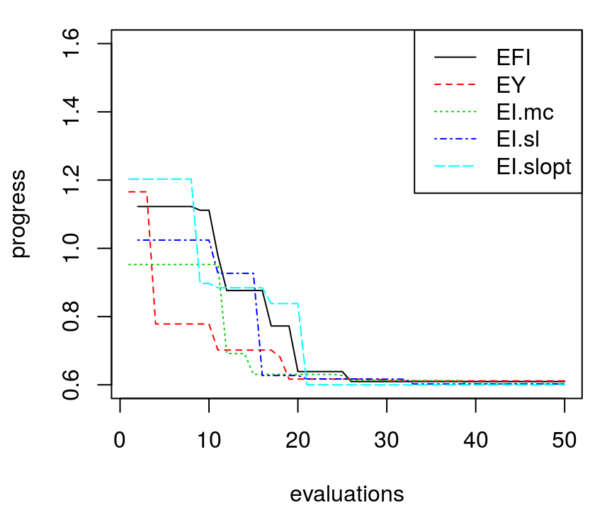

```r
plot(efi$prog, type="l", ylim=c(0.6, 1.6), ylab="progress", xlab="evaluations")
lines(ey$prog, col=2, lty=2); lines(ei.mc$prog, col=3, lty=3)
lines(ei.sl$prog, col=4, lty=4); lines(ei.slopt$prog, col=5, lty=5)
legend("topright", c("EFI", "EY", "EI.mc", "EI.sl", "EI.slopt"), col=1:5, lty=1:5)
```

## Typical behavior

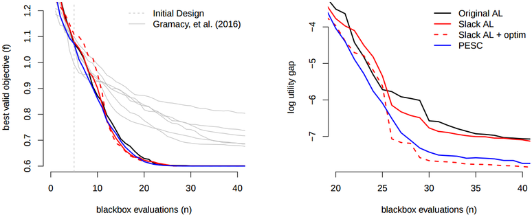

Average results after 100 restarts.

- Pretty speedy.
- Recall that our `optim`-AL required 100+ evaluations for *local* convergence.

## Unknown objective?

Sure, no problem. How about this crazy one?

```r
f2d <- function(x, y=NULL)
  {
    if(is.null(y)) {
      if(!is.matrix(x)) x <- matrix(x, ncol=2)
        y <- x[,2]; x <- x[,1]
    }
    g <- function(z)
        return(exp(-(z-1)^2) + exp(-0.8*(z+1)^2) - 0.05*sin(8*(z+0.1)))
    return(-g(x)*g(y))
  }

aimprob2 <- function(X, known.only = FALSE)
{
  if(is.null(nrow(X))) X <- matrix(X, nrow=1)
  if(known.only) stop("no outputs are treated as known")
  f <- f2d(4*(X-0.5))
  c1 <- 1.5 - X[,1] - 2*X[,2] - 0.5*sin(2*pi*(X[,1]^2 - 2*X[,2]))
  c2 <- rowSums(X^2)-1.5
  return(list(obj=f, c=cbind(c1,c2)))
}
```

## Visualizing sub-routine

Here is a little function to re-draw the surface on-demand.

```r
plot.aimprob2 <- function()
 {
    x <- seq(0,1, length=200)
    X <- expand.grid(x, x)
    out <- aimprob2(as.matrix(X))
    fv <- out$obj
    fv[out$c[,1] > 0 | out$c[,2] > 0] <- NA
    fi <- out$obj
    fi[!(out$c[,1] > 0 | out$c[,2] > 0)] <- NA
    plot(0, 0, type="n", xlim=B[1,], ylim=B[2,], xlab="x1", ylab="x2")
    contour(x, x, matrix(out$c[,1], ncol=length(x)), nlevels=1, levels=0,
        drawlabels=FALSE, add=TRUE, lwd=2)
    contour(x, x, matrix(out$c[,2], ncol=length(x)), nlevels=1, levels=0,
        drawlabels=FALSE, add=TRUE, lwd=2)
    contour(x, x, matrix(fv, ncol=length(x)), nlevels=10, add=TRUE,
        col="forestgreen")
    contour(x, x, matrix(fi, ncol=length(x)), nlevels=13, add=TRUE, col=2, lty=2)
 }
```

## Visualizing

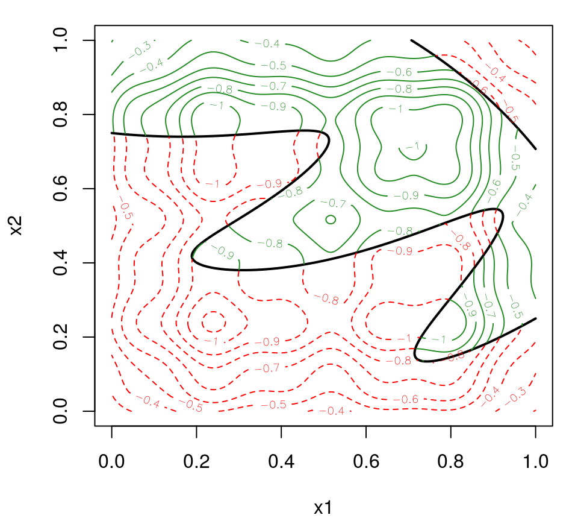

```r
plot.aimprob2()
```

## Optimizing via EI with AL

Pretty fast progress.

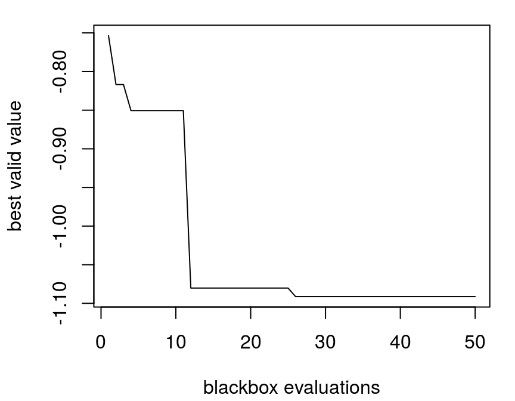

```r
out2 <- optim.auglag(aimprob2, B, fhat=TRUE, start=20, end=50, verb=0)
plot(out2$prog, type="l", ylab="best valid value", xlab="blackbox evaluations")
```

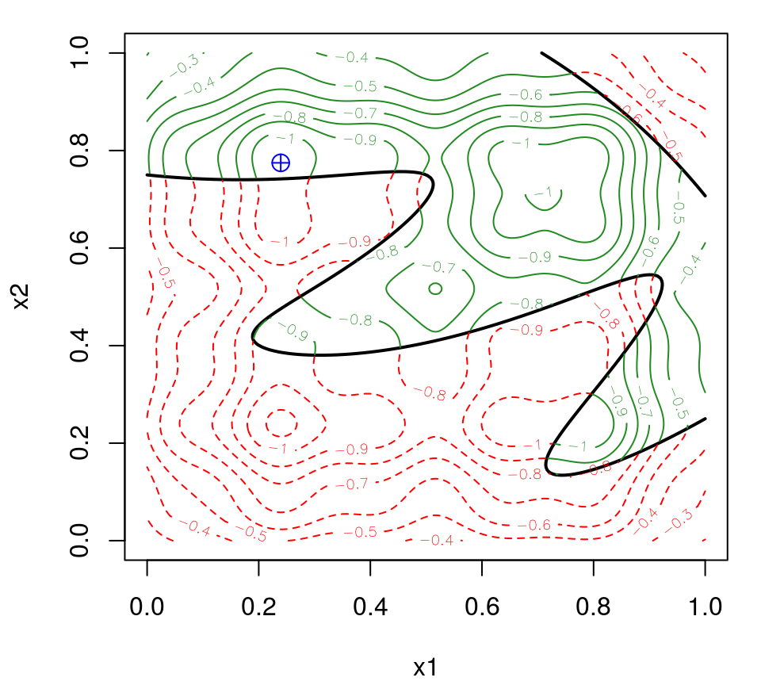

```r
plot.aimprob2()
v <- apply(out2$C, 1, function(x) { all(x <= 0) })
X <- out2$X[v,]; obj <- out2$obj[v]; xbest <- X[which.min(obj),]
points(xbest[1], xbest[2], pch=10, col="blue", cex=1.5)
```

How about initializing an `optim` search from that point to see if we can "drill down" any further?

```r
aimprob2.AL <- function(x, B, lambda, rho)
{
  if(any(x < B[,1]) | any(x > B[,2])) return(Inf)
  fc <- aimprob2(x)
  al <- fc$obj + lambda%*%drop(fc$c) + rep(1/(2*rho),2)%*%pmax(0,drop(fc$c))^2
  return(al)
}

## loop over AL updates until a valid solution is found
lambda <- out2$lambda[nrow(out2$lambda),]; rho <- out2$rho[length(out2$rho)]
while(1) {
    o <- optim(xbest, aimprob2.AL, control=list(maxit=15),
      B=B, lambda=lambda, rho=rho)
    fc <- aimprob2(o$par)

    if(all(fc$c <= 0)) { break
    } else {
      lambda <- pmax(0, lambda + (1/rho)*fc$c)
      rho <- rho/2; xbest <- o$par
    }
  }
```

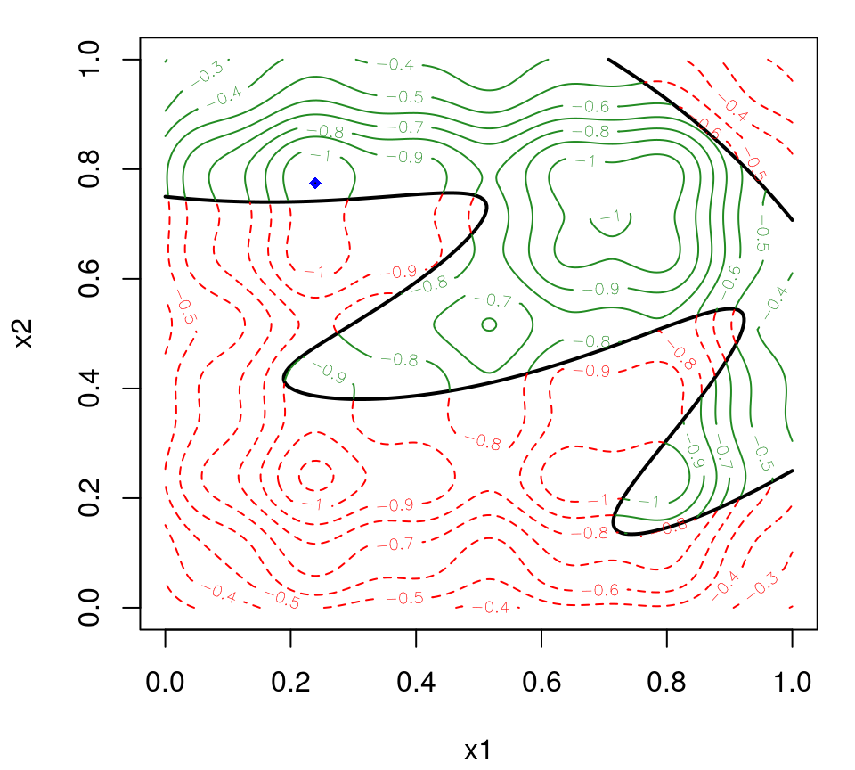

```r
plot.aimprob2()
points(o$par[1], o$par[2], pch=18, col="blue")
segments(xbest[1], xbest[2], o$par[1], o$par[2])
```

## Other demos

For further comparison with `optim` directly on the AL,

- see `demo("ALfhat")` in the `laGP` package.

Two other demos show a mixed constraints setup

- A 2d problem (`"GSBP"`) involving
  - a Goldstein–Price objective
  - the toy sinusoidal inequality constraint
  - and two equality constraints that together trace out four ribbons of valid region
- A 4d problem (`"LAH"`) with
  - a known linear objective
  - an inequality constraint derived from the ["Ackley" function](https://www.sfu.ca/~ssurjano/ackley.html)
  - an equality constraint derived from the ["Hartman" function](https://www.sfu.ca/~ssurjano/hart4.html)

`demo("GSBP")` – such a crazy surface!

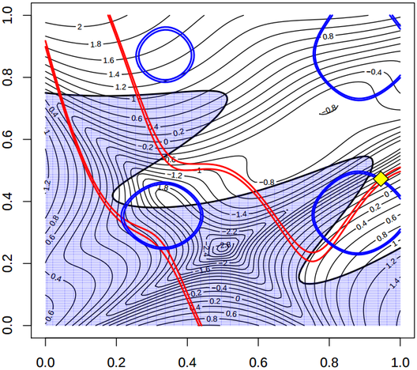